# O365 Satisfy Engineering - Case Notes

```r
#if(!require(bayesian_first_aid)){devtools::install_github("rasmusab/bayesian_first_aid")}
if(!require(easypackages)){install.packages("easypackages")}
library(easypackages)
packages("plyr", "dplyr", "ggplot2", "readr", "gridExtra", "readxl", "tidyr","stringr", "lubridate", prompt = FALSE)
```

# Introduction

> It may take time to truly understand the imapct the new feature may have.

When introducing a new feature in environments similar to O365 Support, it is possible a new feature may increase the time to resolve a ticket. Agents may face a learning curve and also socialize the new feature with peers. Over time, these behavioral impacts should evaporate and the long-term impact of the new feature will be realized.

# Get Data

Import the data provided by Microsoft 1/24/18. The data consists of two files:

1. An Excel file named `AllAgentsDec1.xlsx` containing information of all agents with activity since Dec 1, 2017.
2. An Excel file named `CaseNotesSearchABData.xlsx` with data starting January 15 - a week before the *Search Case Notes* feature was deployed to a subset of CIs (Concierge Insiders). It contains data that will be used as the control group (the data prior to the test) and the test data (the records starting Jan 22). The Excel file has 3 worksheets:
   1. Non-Concierge Insiders with no access to the new feature
   2. Concierge Insiders with access to the new feature
   3. Ticket Data - updated 1/29/2018

Therefore, 4 data sources will be imported.

```r
AllAgents <- read_excel("~/Github/Valorem/ClientProjects/MS_O365/data/AllAgentsDec1.xlsx")

ABData_NCI <- read_excel("~/Github/Valorem/ClientProjects/MS_O365/data/CaseNotesSearchABData.xlsx", sheet = "Non_Insiders")

ABData_CI <- read_excel("~/Github/Valorem/ClientProjects/MS_O365/data/CaseNotesSearchABData.xlsx", sheet = "Insiders")

ABData_TicketData <- read_excel("~/Github/Valorem/ClientProjects/MS_O365/data/CaseNotesSearchAB_Jan29.xlsx")
```

`ABData_TicketData` has an extra variable so remove it.

```r
ABData_TicketData <- ABData_TicketData %>% select(-RequestId__1)
```

Filter ticket data to remove `IsResolved = NULL`. First change variable to `Int` then filter on `na`.

```r
ABData_TicketData$IsResolved <- as.integer(ABData_TicketData$IsResolved)
ABData_TicketData <- filter(ABData_TicketData, !is.na(IsResolved))
```

In previous data exploratory analyses, the distribution of the log(TTR) resulted in a bi-modal distribution. Check to see if this persists in a much smaller data set.

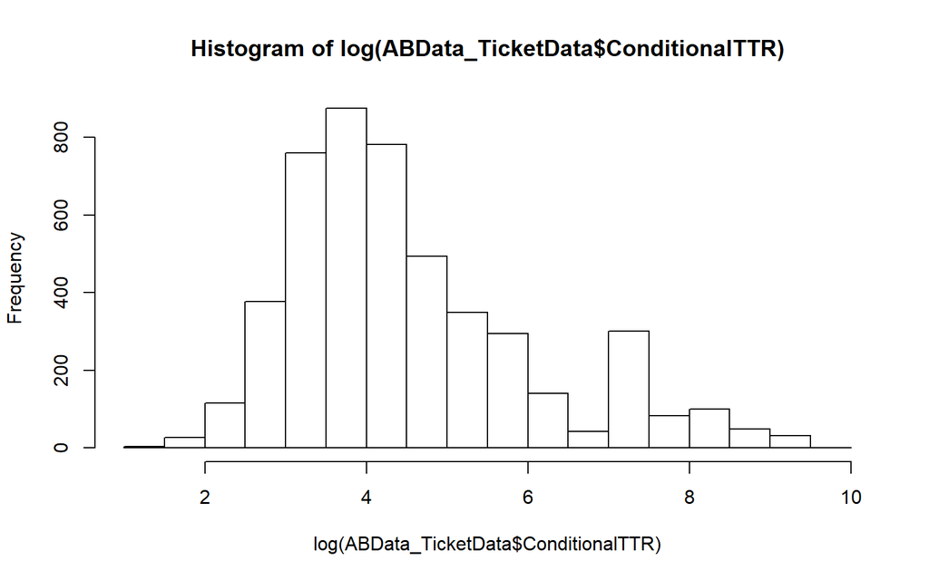

```r
ABData_TicketData$ConditionalTTR <- as.integer(ABData_TicketData$ConditionalTTR)
ABData_TicketData <- ABData_TicketData %>% mutate(ConditionalTTR = ifelse(is.na(ConditionalTTR), 0, ConditionalTTR))

hist(log(ABData_TicketData$ConditionalTTR))
```

Because the bi-modal distribution is evident, later in the analysis, it will be necessary to limit data analysis to the first peak.

It is always easier to analyze fewer files, so combine `ABData_CI` and `ABData_NCI` into one source. First add a column to each to noting the agents are `CIs` or `NCIs`.

```r
ABData_CI <- ABData_CI %>% mutate(InsiderRole = "CI")
ABData_NCI <- ABData_NCI %>% mutate(InsiderRole = "NCI")

ABData <- rbind(ABData_NCI, ABData_CI)
rm(ABData_CI, ABData_NCI)
```

Join the ABData Agents with `ABData_TicketData`.

```r
ABData_complete <-left_join(ABData_TicketData, ABData, by = "AgentID")
#Using left join rather than inner join to identify any tickets where we are missing an Agent

rm(ABData)

glimpse(ABData_complete)
```

```
## Observations: 25,626
## Variables: 16
## $ RequestId        <chr> "337ECC2D-B53A-4402-B949-62B780A1E116", "7E13...
## $ OrganizationId.x <chr> "C55C07C1-EF42-4305-ACDE-81C739C63763", "A488...
## $ AgentID          <chr> "B55BE73E-A10F-400F-A67F-198543E4C601", "D934...
## $ CreateDateTime   <chr> "2018-01-15 00:05:50.3545249 +00:00", "2018-0...
## $ ResolvedTime     <chr> "2018-01-15 00:42:35.1668071 +00:00", "2018-0...
## $ IsResolved       <int> 1, 1, 1, 0, 1, 1, 1, 1, 0, 1, 1, 1, 1, 1, 1, ...
## $ CSATScore        <chr> "5", "5", "5", "5", "5", "5", "5", "5", "5", ...
## $ ReScenario       <chr> "No ReScenario", "No ReScenario", "No ReScena...
## $ ModalityChannel  <chr> "IVRTicket", "IVRTicket", "IVRTicket", "IVRTi...
## $ ConditionalTTR   <dbl> 35, 98, 48, 87, 300, 391, 141, 30, 20, 433, 5...
## $ OrganizationId.y <chr> "C55C07C1-EF42-4305-ACDE-81C739C63763", "A488...
## $ FirstName        <chr> "Amy", "Mashy", "Angus", "Shado", "Ram", "Joy...
## $ LastName         <chr> "Hu", "Santiago", "Huai", "Zhou", "Cauntay", ...
## $ Email            <chr> "v-amhu@microsoft.com", "ray.marlo.p.santiago...
## $ Roles            <chr> "Agent,PartnerAdmin,EscalationEngineer", "Age...
## $ InsiderRole      <chr> "NCI", "NCI", "CI", "NCI", "NCI", "NCI", "NCI...
```

Remove redundant variable:

```r
ABData_complete <- ABData_complete %>% select(-OrganizationId.y)
ABData_complete <- plyr::rename(ABData_complete, c("OrganizationId.x" = "OrganizationId"))
```

# Explore and Clean Data

Some records (117) are not associated with a CI or NCI agent. Remove them.

```r
ABData_complete <- filter(ABData_complete, !is.na(InsiderRole))
```

Make `CreateDateTime` a date field.

```r
ABData_complete$createDate <- str_sub(ABData_complete$CreateDateTime, 1, 10)
ABData_complete$createDate <- as.Date(ABData_complete$createDate)
```

Recall the log(TTR) histogram produces a bi-modal distribution. Therefore, we must consider this in the analysis that follows.

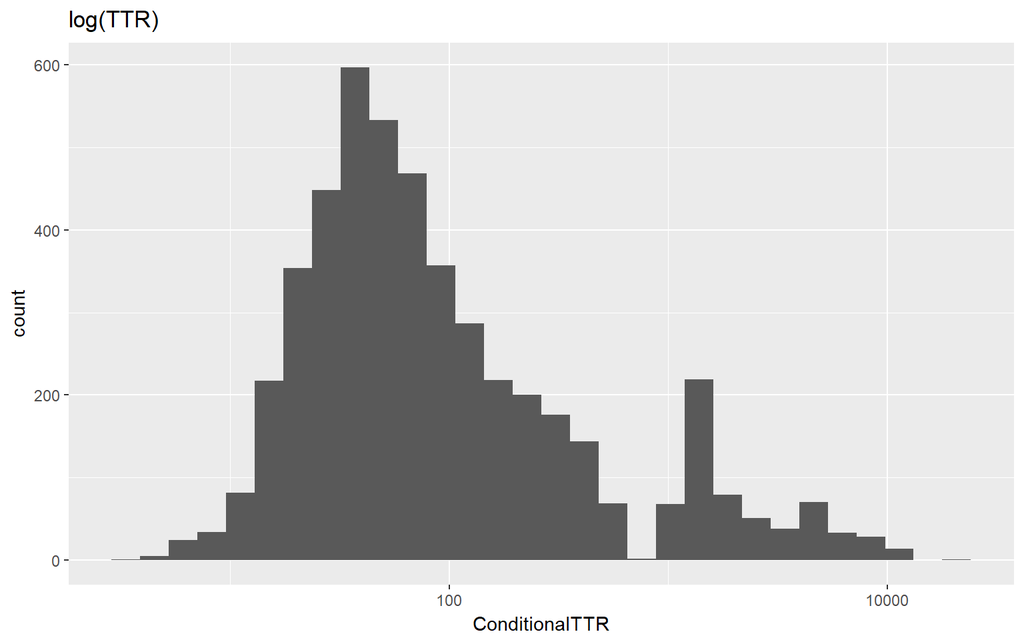

```r
p1 <- ggplot(aes(x = ConditionalTTR), data = ABData_complete) + geom_histogram() + scale_x_log10() + ggtitle("log(TTR)")
p1
```

```r
p1Data <- ggplot_build(p1)
#Gets values actually plotted you can use function ggplot_build() where argument is your plot.

# This will make list and one of sublists is named data. This sublist contains dataframe with values used in plot, for example, for histogram it contains y values (the same as count). If you use facets then column PANEL shows in which facet values are used. If there are more than one geom_ in your plot then data will contains dataframes for each
#If you need just data it seems layer_data is designed precisely for this: layer_data(p2,1)
layer_data(p1,1)
```

```
##      y count         x      xmin      xmax     density      ncount
## 1    1     1 0.5232590 0.4578516 0.5886663 0.001586963 0.001675042
## 2    5     5 0.6540737 0.5886663 0.7194811 0.007934813 0.008375209
## 3   24    24 0.7848884 0.7194811 0.8502958 0.038087101 0.040201005
## 4   34    34 0.9157032 0.8502958 0.9811105 0.053956726 0.056951424
## 5   82    82 1.0465179 0.9811105 1.1119253 0.130130928 0.137353434
## 6  217   217 1.1773327 1.1119253 1.2427400 0.344370870 0.363484087
## 7  354   354 1.3081474 1.2427400 1.3735548 0.561784737 0.592964824
## 8  448   448 1.4389621 1.3735548 1.5043695 0.710959216 0.750418760
## 9  597   597 1.5697769 1.5043695 1.6351842 0.947416634 1.000000000
## 10 533   533 1.7005916 1.6351842 1.7659990 0.845851031 0.892797320
## 11 468   468 1.8314063 1.7659990 1.8968137 0.742698466 0.783919598
## 12 357   357 1.9622211 1.8968137 2.0276285 0.566545625 0.597989950
## 13 287   287 2.0930358 2.0276285 2.1584432 0.455458248 0.480737018
## 14 218   218 2.2238506 2.1584432 2.2892579 0.345957833 0.365159129
```

[output cut: 47 more lines]

Evaluating all the data, find the max and min values of the peaks using the data above.

The first peak in the bi-modal distribution will be used in the analysis. Therefore, filter the data by x < 658. (The anti-log of 2.818 = 658.)

```r
ABData_complete <- ABData_complete %>% filter(ConditionalTTR < 658)
```

Add a column to facilitate the statistical analysis.

```r
ABData_complete <- ABData_complete %>% mutate(dateLive = if_else(createDate < '2018-01-22', "Prior", "Post"))
```

# TTR Analysis

Filter ticket data to remove `ConditionalTTR = 0`. **How can TTR = 0?**

```r
TTR <- ABData_complete %>% filter(ConditionalTTR > 0)
```

## Methodology

During a Team Meeting Friday, January 19, 2018, the Team identified the methodology to be used in in this analysis.

- Data will be collected before the Case Notes feature was implemented and after implementation
- When the Case Notes feature is implemented, all CIs will get the new feature
- The difference between the mean TTR for CIs before and after the Case Notes feature is implemented will be used to calculate the impact of the new feature.

> This methodology is not ideal but adapted to the limitations the data store. There is no way to randomly selected CI and NCI agents. This prevents running the test with two populations simultaneously. This forces the analysis to use before/after data. This introduces risk - other factors could influence the results since the data is collected at different times.

## CI TTR Mean Analysis

```r
TTR_CI <- TTR %>% filter(InsiderRole == 'CI')
```

Evaluate 353 CI records.

```r
t_CI <- t.test(ConditionalTTR ~ dateLive, TTR_CI)
t_CI
```

```
##
##  Welch Two Sample t-test
##
## data:  ConditionalTTR by dateLive
## t = -0.22075, df = 321.17, p-value = 0.8254
## alternative hypothesis: true difference in means is not equal to 0
## 95 percent confidence interval:
##  -26.43534  21.10147
## sample estimates:
##  mean in group Post mean in group Prior
##            93.05181            95.71875
```

The TTR Mean for the CI group before Case Notes Search was implemented was 95.71875. The TTR Mean after the feature was implemented for the CI Group was 93.0518135. A p-value = 0.8254275 > 0.05 suggests there is no statistical difference in TTR Mean.

> The Case Notes Feature did not change the mean TTR for the CI Group.

Note, while not statistically significant, the mean TTR dropped after the new feature was implemented.

Evaluate NCI to see if the Post and Prior TTR Means follow the same patter where Post < Prior.

```r
TTR_NCI <- TTR %>% filter(InsiderRole == 'NCI')
t_NCI <- t.test(ConditionalTTR ~ dateLive, TTR_NCI)
t_NCI
```

```
##
##  Welch Two Sample t-test
##
## data:  ConditionalTTR by dateLive
## t = -3.5695, df = 3760.9, p-value = 0.0003621
## alternative hypothesis: true difference in means is not equal to 0
## 95 percent confidence interval:
##  -19.347514  -5.628879
## sample estimates:
##  mean in group Post mean in group Prior
##            89.88761           102.37580
```

Yes, NCI Post < NCI Prior. Why the NCI TTR Mean dropped in a statistically significant way is not known. There may have been confounding changes in the prior week versus the week the case search feature was implemented.

# Agent Reopen

```r
rm(list= ls()[!(ls() %in% c('ABData_complete','AllAgents'))])

v1_1 <- nrow(filter(ABData_complete, ReScenario == 'Agent Reopen' & dateLive == "Prior"))
v1_2 <- nrow(filter(ABData_complete, ReScenario == 'Agent Reopen' & dateLive == "Post"))
myVectorPositive <- c(v1_1, v1_2)
v2_1 <- nrow(filter(ABData_complete, dateLive == "Prior"))
v2_2<- nrow(filter(ABData_complete, dateLive == "Post"))
myVectorTotal <- c(v2_1, v2_2)

prop.test(myVectorPositive, myVectorTotal, correct =  F)
```

```
##
##  2-sample test for equality of proportions without continuity
##  correction
##
## data:  myVectorPositive out of myVectorTotal
## X-squared = 0.23001, df = 1, p-value = 0.6315
## alternative hypothesis: two.sided
## 95 percent confidence interval:
##  -0.001393573  0.002295957
## sample estimates:
##      prop 1      prop 2
## 0.005769075 0.005317882
```

> Agent Reopen proportions did not statistically change for the 2 weeks + analyzed.

# Customer Reopen

```r
v1_1 <- nrow(filter(ABData_complete, ReScenario == 'Customer Reopen' & dateLive == "Prior"))
v1_2 <- nrow(filter(ABData_complete, ReScenario == 'Customer Reopen' & dateLive == "Post"))
myVectorPositive <- c(v1_1, v1_2)

prop.test(myVectorPositive, myVectorTotal, correct =  F)
```

```
##
##  2-sample test for equality of proportions without continuity
##  correction
##
## data:  myVectorPositive out of myVectorTotal
## X-squared = 0.15717, df = 1, p-value = 0.6918
## alternative hypothesis: two.sided
## 95 percent confidence interval:
##  -0.003408989  0.002261674
## sample estimates:
##     prop 1     prop 2
## 0.01291948 0.01349313
```

> Customer Reopen proportions did not statistically change for the 2 weeks + analyzed.

# Repeat Caller

```r
v1_1 <- nrow(filter(ABData_complete, ReScenario == 'Repeat Caller' & dateLive == "Prior"))
v1_2 <- nrow(filter(ABData_complete, ReScenario == 'Repeat Caller' & dateLive == "Post"))
myVectorPositive <- c(v1_1, v1_2)

prop.test(myVectorPositive, myVectorTotal, correct =  F)
```

```
##
##  2-sample test for equality of proportions without continuity
##  correction
##
## data:  myVectorPositive out of myVectorTotal
## X-squared = 156.14, df = 1, p-value < 2.2e-16
## alternative hypothesis: two.sided
## 95 percent confidence interval:
##  0.01570379 0.02157804
## sample estimates:
##      prop 1      prop 2
## 0.023482571 0.004841654
```

> Repeat Caller proportions did change for the 2 weeks + analyzed in a statistically significant way.

# IsResolved

```r
v1_1 <- nrow(filter(ABData_complete, IsResolved ==TRUE & dateLive == "Prior"))
v1_2 <- nrow(filter(ABData_complete, IsResolved ==TRUE & dateLive == "Post"))
myVectorPositive <- c(v1_1, v1_2)

prop.test(myVectorPositive, myVectorTotal, correct =  F)
```

```
##
##  2-sample test for equality of proportions without continuity
##  correction
##
## data:  myVectorPositive out of myVectorTotal
## X-squared = 0.26263, df = 1, p-value = 0.6083
## alternative hypothesis: two.sided
## 95 percent confidence interval:
##  -0.003455611  0.005903115
## sample estimates:
##    prop 1    prop 2
## 0.9637605 0.9625367
```

> IsResolved proportions did not statistically change for the 2 weeks + analyzed.

# Appendix

## t-Test Bayesian Approach (WIP)

To be evaluated:

See http://www.sumsar.net/blog/2014/02/bayesian-first-aid-one-sample-t-test/

Installing JAGS is troublesome. Need to investigate.

```r
#library(BayesianFirstAid)
```

## Historical TTR Means

In previous efforts, a larger data set was used to calculate TTR means (among other statistical analyses).

```r
myData <- read_excel("~/Github/Valorem/ClientProjects/MS_O365/data/CaseNotesSearchABHistorical_Dec13.xlsx")

myData2 <- myData %>% mutate(Date = as.Date(CreateDateTime), Hour = hour(CreateDateTime), ReScenario = factor(ReScenario)) %>%
  filter(TTR > 0) %>% drop_na(IsResolved, Roles) %>% mutate(Concierge = str_detect(Roles, "FirstRelease")) %>%
  mutate(Agent = str_detect(Roles, "Agent")) %>%
  select(-RequestID, -PartnerId,-CreateDateTime,  -Date, -Hour)
# remove 3 records where Agent = FALSE and Rave2 = FALSE:  table(myData2$Agent)
myData2 <- filter(myData2, Agent == TRUE)
myData2 <- myData2 %>% mutate(NewRole = ifelse(Concierge == TRUE, "Concierge", "Agent"))

p1 <- ggplot(aes(x = TTR), data = myData2) + geom_histogram() + scale_x_log10() + ggtitle("log(TTR)")

p1Data <- ggplot_build(p1)
#Get values actually plotted you can use function ggplot_build() where argument is your plot.

# This will make list and one of sublists is named data. This sublist contains dataframe with values used in plot, for example, for histrogramm it contains y values (the same as count). If you use facets then column PANEL shows in which facet values are used. If there are more than one geom_ in your plot then data will contains dataframes for each
#If you need just data it seems layer_data is designed precisely for this: layer_data(p2,1)
layer_data(p1,1)
```

```
##        y count         x       xmin      xmax      density      ncount
## 1    830   830 0.0000000 -0.0879157 0.0879157 0.0288849176 0.039321584
## 2      0     0 0.1758314  0.0879157 0.2637471 0.0000000000 0.000000000
## 3   1649  1649 0.3516628  0.2637471 0.4395785 0.0573870231 0.078122039
## 4   4438  4438 0.5274942  0.4395785 0.6154099 0.1544473065 0.210252037
## 5   5274  5274 0.7033256  0.6154099 0.7912413 0.1835410308 0.249857874
## 6   9108  9108 0.8791570  0.7912413 0.9670727 0.3169684696 0.431495168
## 7  12851 12851 1.0549884  0.9670727 1.1429041 0.4472290077 0.608821300
## 8  18787 18787 1.2308198  1.1429041 1.3187355 0.6538083704 0.890041690
## 9  21108 21108 1.4066512  1.3187355 1.4945669 0.7345817365 1.000000000
## 10 17229 17229 1.5824826  1.4945669 1.6703983 0.5995882480 0.816230813
## 11 14704 14704 1.7583140  1.6703983 1.8462297 0.5117154564 0.696607921
## 12  9912  9912 1.9341454  1.8462297 2.0220611 0.3449485585 0.469584991
## 13  6523  6523 2.1099768  2.0220611 2.1978925 0.2270076117 0.309029752
## 14  4502  4502 2.2858082  2.1978925 2.3737239 0.1566745773 0.213284063
```

[output cut: 47 more lines]

The minimum value after the first peak is y = 246, x = 2.813. The antilogarithm of 2.813 = 650.

```r
myData2 <- myData2 %>% filter(TTR < 650, NewRole == "Concierge")
mean(myData2$TTR)
```

```
## [1] 46.78492
```